# Chapter4

Pekka Tolli

23 November 2018

# Week 4 - total clusterfun

## Data analysis

On this week’s exercise I’ll explore the Boston crime data set from MASS library. I’ll do cluster analysis of the data set.

## Part 1: Explore the basics of the dataset:

```r
str(Boston)
```

```
## 'data.frame':    506 obs. of  14 variables:
##  $ crim   : num  0.00632 0.02731 0.02729 0.03237 0.06905 ...
##  $ zn     : num  18 0 0 0 0 0 12.5 12.5 12.5 12.5 ...
##  $ indus  : num  2.31 7.07 7.07 2.18 2.18 2.18 7.87 7.87 7.87 7.87 ...
##  $ chas   : int  0 0 0 0 0 0 0 0 0 0 ...
##  $ nox    : num  0.538 0.469 0.469 0.458 0.458 0.458 0.524 0.524 0.524 0.524 ...
##  $ rm     : num  6.58 6.42 7.18 7 7.15 ...
##  $ age    : num  65.2 78.9 61.1 45.8 54.2 58.7 66.6 96.1 100 85.9 ...
##  $ dis    : num  4.09 4.97 4.97 6.06 6.06 ...
##  $ rad    : int  1 2 2 3 3 3 5 5 5 5 ...
##  $ tax    : num  296 242 242 222 222 222 311 311 311 311 ...
##  $ ptratio: num  15.3 17.8 17.8 18.7 18.7 18.7 15.2 15.2 15.2 15.2 ...
##  $ black  : num  397 397 393 395 397 ...
##  $ lstat  : num  4.98 9.14 4.03 2.94 5.33 ...
##  $ medv   : num  24 21.6 34.7 33.4 36.2 28.7 22.9 27.1 16.5 18.9 ...
```

```r
dim(Boston)
```

```
## [1] 506  14
```

We have data set with 14 variables and ~500 observations.

**Variables include:**  
crim = per capita crime rate by town.  
zn = proportion of residential land zoned for lots over 25,000 sq.ft.  
indus = proportion of non-retail business acres per town.  
chas = Charles River dummy variable (= 1 if tract bounds river; 0 otherwise).  
nox = nitrogen oxides concentration (parts per 10 million).  
rm = average number of rooms per dwelling.  
age = proportion of owner-occupied units built prior to 1940.  
dis = weighted mean of distances to five Boston employment centres.  
rad = index of accessibility to radial highways.  
tax = full-value property-tax rate per $10,000.  
ptratio = pupil-teacher ratio by town.  
black = 1000(Bk - 0.63)^2 where Bk is the proportion of blacks by town.  
lstat = lower status of the population (percent).  
medv = median value of owner-occupied homes in $1000s.

```r
kable(summary(Boston), caption = " Summary of Boston data set")
```

Summary of Boston data set

|  | crim | zn | indus | chas | nox | rm | age | dis | rad | tax | ptratio | black | lstat | medv |
| --- | --- | --- | --- | --- | --- | --- | --- | --- | --- | --- | --- | --- | --- | --- |
|  | Min. : 0.00632 | Min. : 0.00 | Min. : 0.46 | Min. :0.00000 | Min. :0.3850 | Min. :3.561 | Min. : 2.90 | Min. : 1.130 | Min. : 1.000 | Min. :187.0 | Min. :12.60 | Min. : 0.32 | Min. : 1.73 | Min. : 5.00 |
|  | 1st Qu.: 0.08204 | 1st Qu.: 0.00 | 1st Qu.: 5.19 | 1st Qu.:0.00000 | 1st Qu.:0.4490 | 1st Qu.:5.886 | 1st Qu.: 45.02 | 1st Qu.: 2.100 | 1st Qu.: 4.000 | 1st Qu.:279.0 | 1st Qu.:17.40 | 1st Qu.:375.38 | 1st Qu.: 6.95 | 1st Qu.:17.02 |
|  | Median : 0.25651 | Median : 0.00 | Median : 9.69 | Median :0.00000 | Median :0.5380 | Median :6.208 | Median : 77.50 | Median : 3.207 | Median : 5.000 | Median :330.0 | Median :19.05 | Median :391.44 | Median :11.36 | Median :21.20 |
|  | Mean : 3.61352 | Mean : 11.36 | Mean :11.14 | Mean :0.06917 | Mean :0.5547 | Mean :6.285 | Mean : 68.57 | Mean : 3.795 | Mean : 9.549 | Mean :408.2 | Mean :18.46 | Mean :356.67 | Mean :12.65 | Mean :22.53 |
|  | 3rd Qu.: 3.67708 | 3rd Qu.: 12.50 | 3rd Qu.:18.10 | 3rd Qu.:0.00000 | 3rd Qu.:0.6240 | 3rd Qu.:6.623 | 3rd Qu.: 94.08 | 3rd Qu.: 5.188 | 3rd Qu.:24.000 | 3rd Qu.:666.0 | 3rd Qu.:20.20 | 3rd Qu.:396.23 | 3rd Qu.:16.95 | 3rd Qu.:25.00 |
|  | Max. :88.97620 | Max. :100.00 | Max. :27.74 | Max. :1.00000 | Max. :0.8710 | Max. :8.780 | Max. :100.00 | Max. :12.127 | Max. :24.000 | Max. :711.0 | Max. :22.00 | Max. :396.90 | Max. :37.97 | Max. :50.00 |

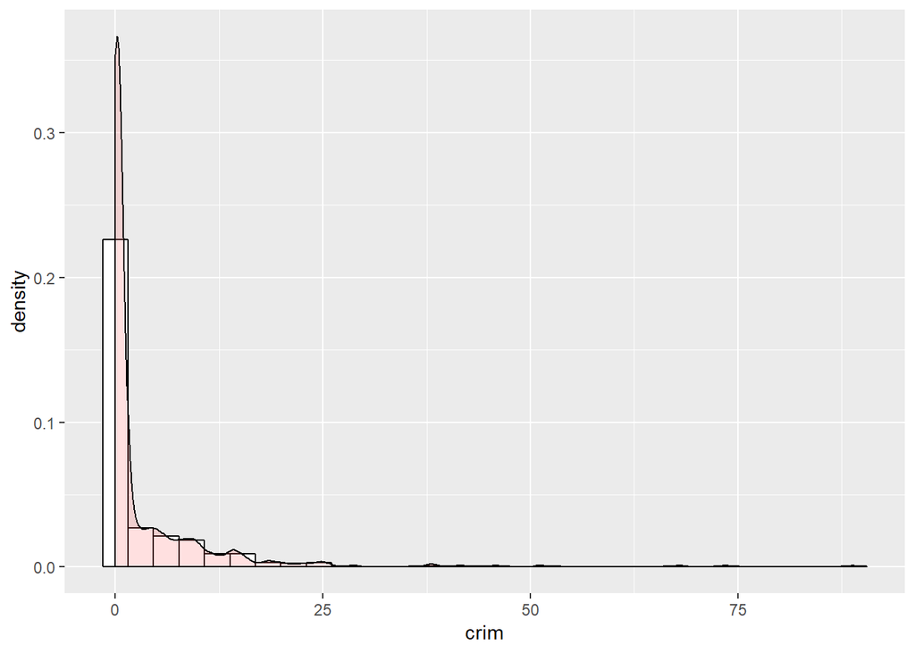

```r
ggplot(Boston, aes(x=crim)) + geom_histogram(aes(y=..density..), colour="black", fill="white")+  geom_density(alpha=.2, fill="#FF6666")
```

Crime rate is continuous variable with great majority at the low end with <1. The range is high with maximum value close to 90.

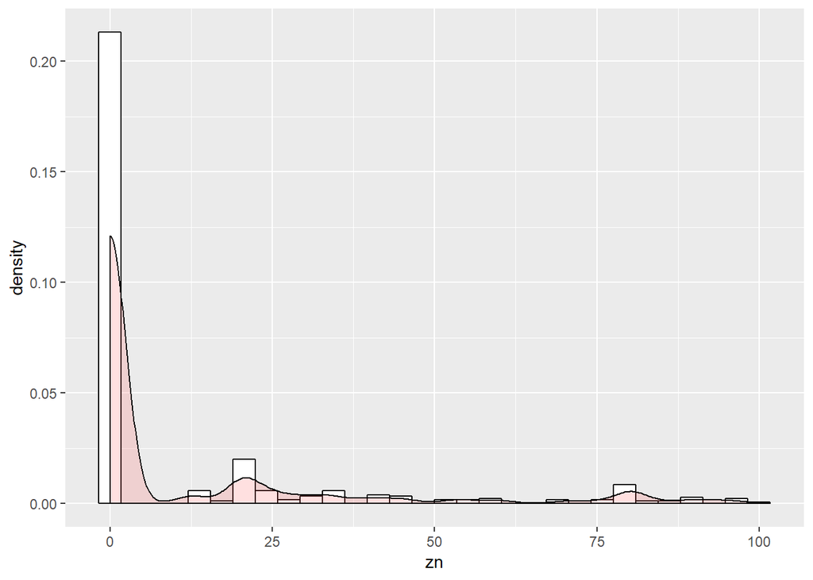

```r
ggplot(Boston, aes(x=zn)) + geom_histogram(aes(y=..density..), colour="black", fill="white")+  geom_density(alpha=.2, fill="#FF6666")
```

proportion of residential land zoned for lots is packed to the low end with median being 0.

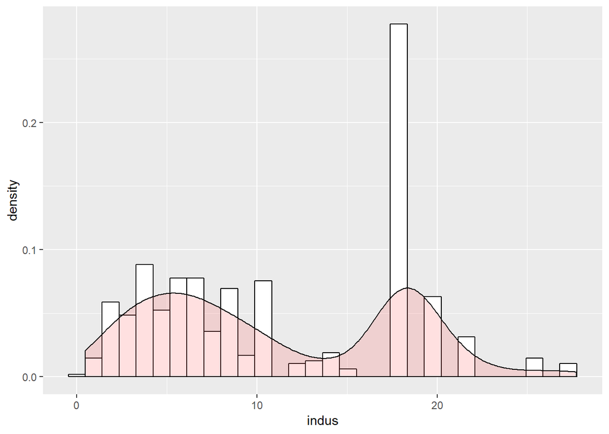

```r
ggplot(Boston, aes(x=indus)) + geom_histogram(aes(y=..density..), colour="black", fill="white")+  geom_density(alpha=.2, fill="#FF6666")
```

proportion of non-retail business acres per town varies between 0-28 with median around 10.

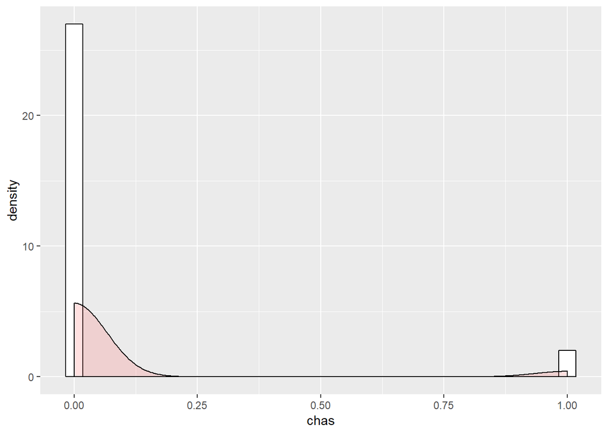

```r
ggplot(Boston, aes(x=chas)) + geom_histogram(aes(y=..density..), colour="black", fill="white")+  geom_density(alpha=.2, fill="#FF6666")
```

chas is a dummy variable with >90% being 0 (not bounding to river)

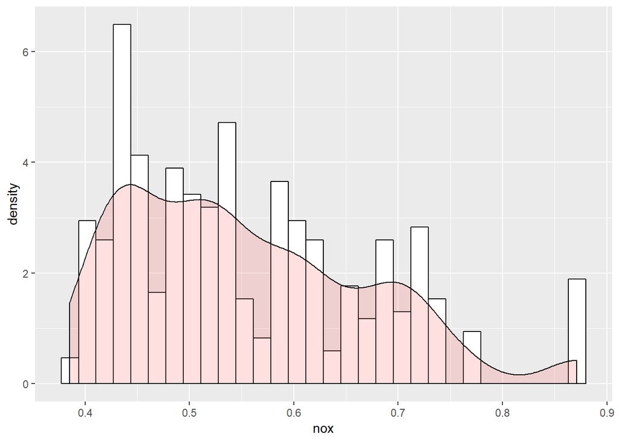

```r
ggplot(Boston, aes(x=nox)) + geom_histogram(aes(y=..density..), colour="black", fill="white")+  geom_density(alpha=.2, fill="#FF6666")
```

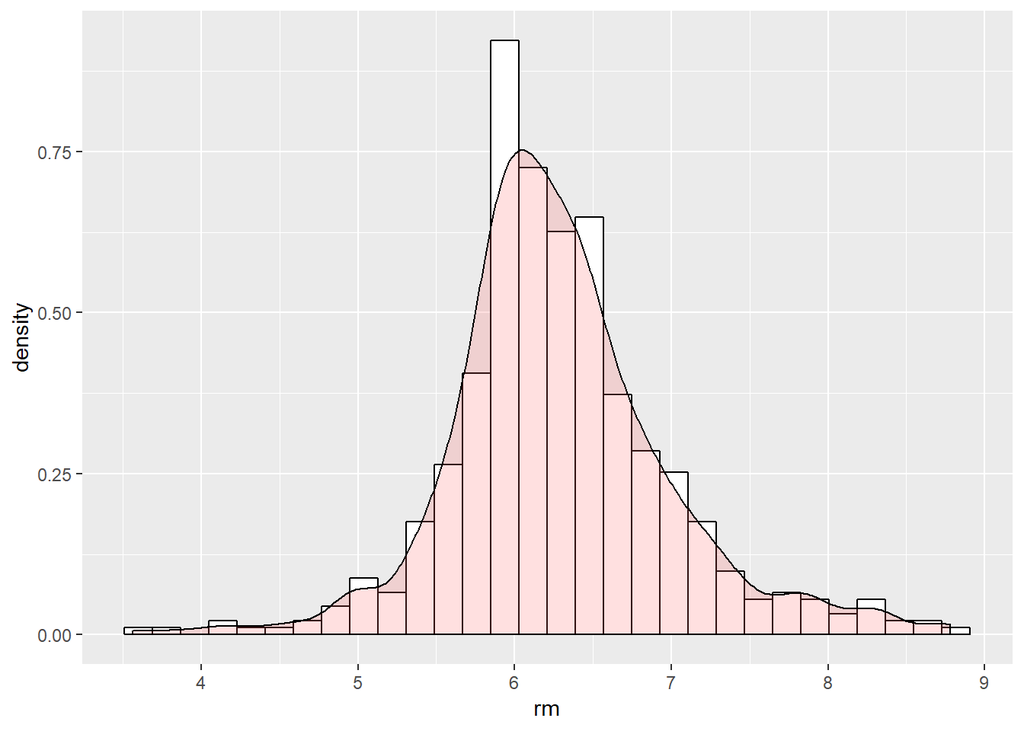

```r
ggplot(Boston, aes(x=rm)) + geom_histogram(aes(y=..density..), colour="black", fill="white")+  geom_density(alpha=.2, fill="#FF6666")
```

number of rooms appeas somewhat normally distributed with median close to 6.

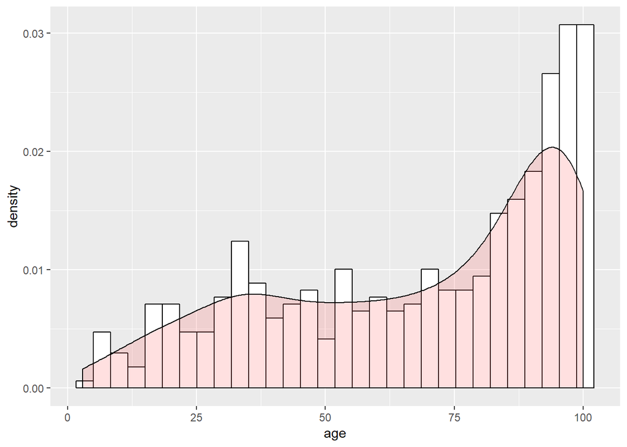

```r
ggplot(Boston, aes(x=age)) + geom_histogram(aes(y=..density..), colour="black", fill="white")+  geom_density(alpha=.2, fill="#FF6666")
```

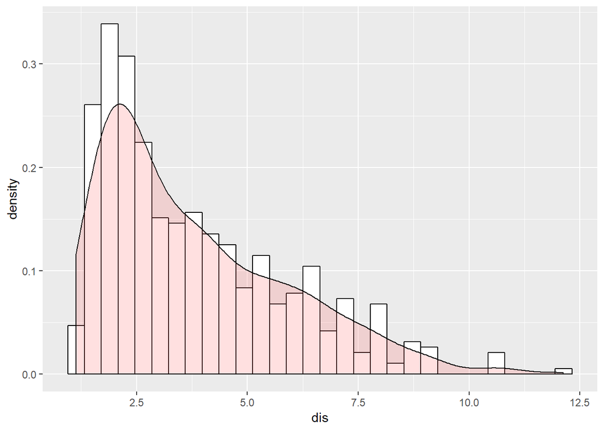

```r
ggplot(Boston, aes(x=dis)) + geom_histogram(aes(y=..density..), colour="black", fill="white")+  geom_density(alpha=.2, fill="#FF6666")
```

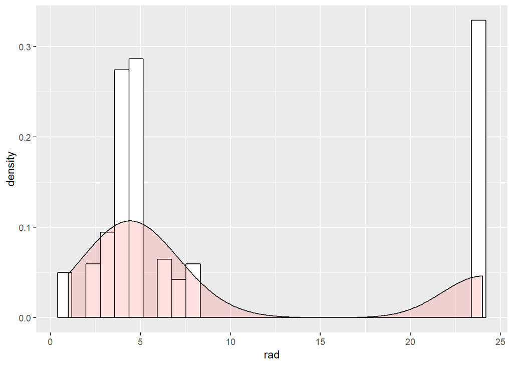

```r
ggplot(Boston, aes(x=rad)) + geom_histogram(aes(y=..density..), colour="black", fill="white")+  geom_density(alpha=.2, fill="#FF6666")
```

access to radial highway is two humped, accessibility is either very low or very high

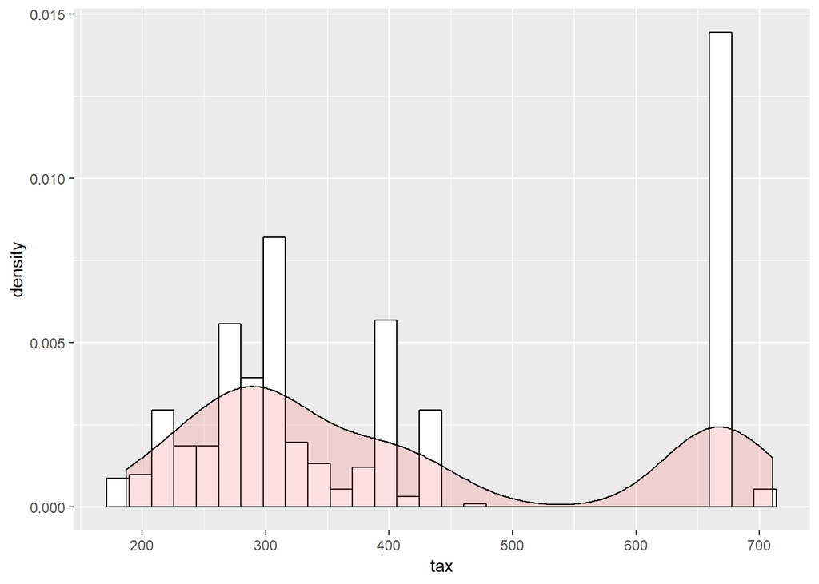

```r
ggplot(Boston, aes(x=tax)) + geom_histogram(aes(y=..density..), colour="black", fill="white")+  geom_density(alpha=.2, fill="#FF6666")
```

property tax rate is mostly between 200-450 but significant amount is focused around 700 as well.

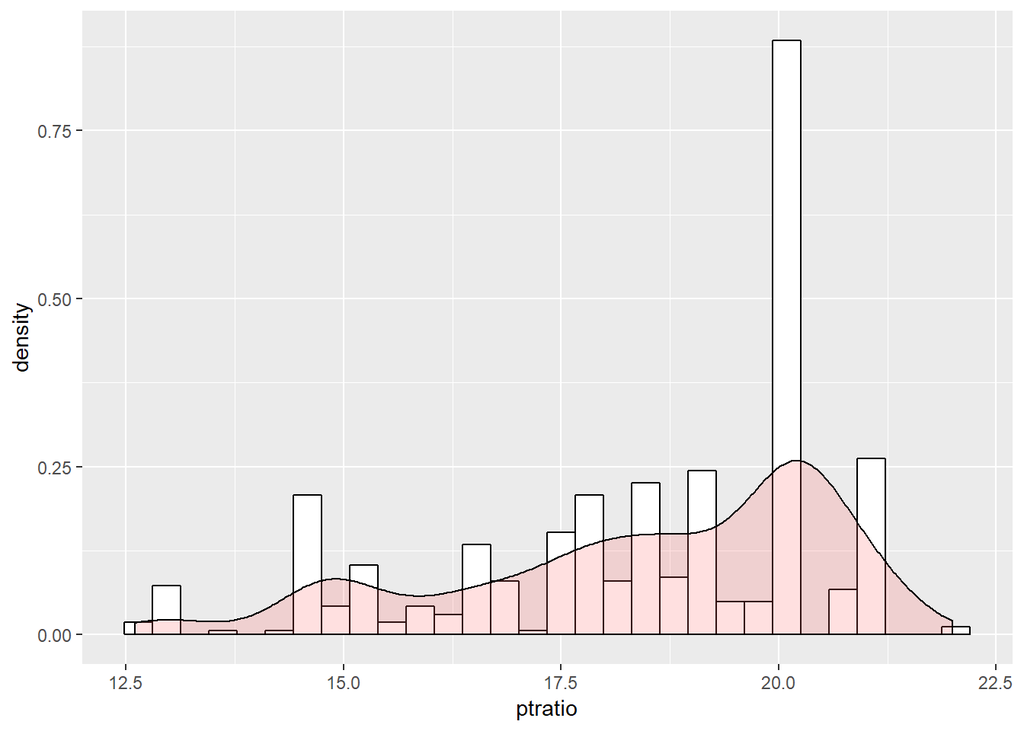

```r
ggplot(Boston, aes(x=ptratio)) + geom_histogram(aes(y=..density..), colour="black", fill="white")+  geom_density(alpha=.2, fill="#FF6666")
```

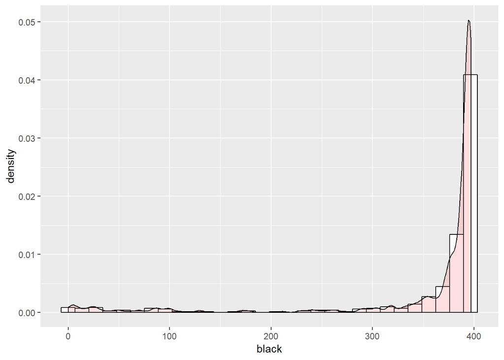

```r
ggplot(Boston, aes(x=black)) + geom_histogram(aes(y=..density..), colour="black", fill="white")+  geom_density(alpha=.2, fill="#FF6666")
```

adjusted black proportion is highly concentrated around 400

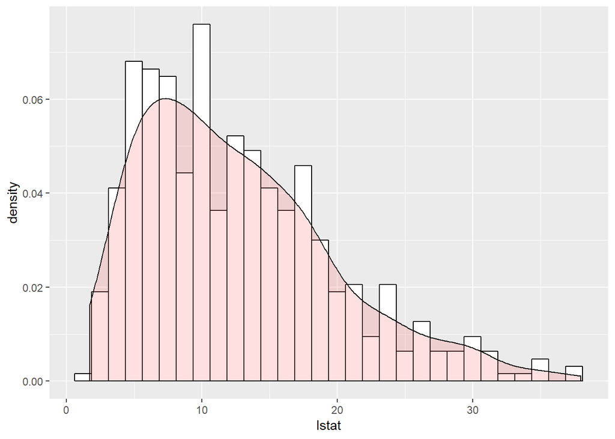

```r
ggplot(Boston, aes(x=lstat)) + geom_histogram(aes(y=..density..), colour="black", fill="white")+  geom_density(alpha=.2, fill="#FF6666")
```

lower status of population is mostly betweeen 0-30 median being around 11

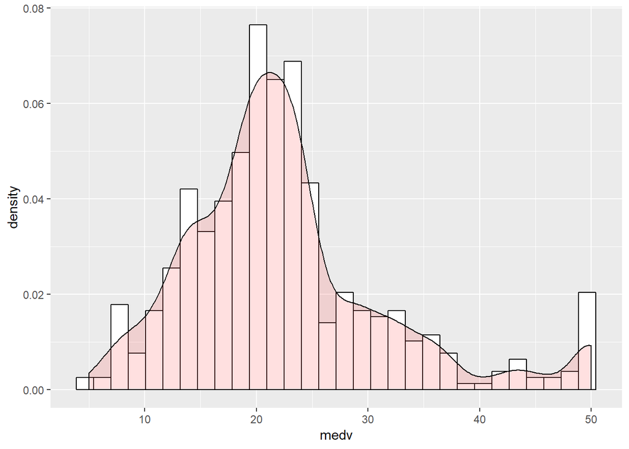

```r
ggplot(Boston, aes(x=medv)) + geom_histogram(aes(y=..density..), colour="black", fill="white")+  geom_density(alpha=.2, fill="#FF6666")
```

median value of owner-occupied homes is 0-50 median being 20.